# Lab 3 - Clustering Assignments

Tran Cong Tuan Manh

2022/04/05

### Câu hỏi 1 (4 điểm)

Ở câu hỏi này, bạn sẽ tiếp tục sử dụng các thuật toán `kmeans` và `hclust` trên tập dữ liệu `USArrests` nhưng có thực hiện thêm một số bước.

#### a. (0.5 điểm) Áp dụng hàm `scale()` trên dữ liệu trước khi thực hiện `k-means` (xem mục 2 trong phần hướng dẫn).

```r
df <- USArrests
summary(df)
```

```
##      Murder          Assault         UrbanPop          Rape
##  Min.   : 0.800   Min.   : 45.0   Min.   :32.00   Min.   : 7.30
##  1st Qu.: 4.075   1st Qu.:109.0   1st Qu.:54.50   1st Qu.:15.07
##  Median : 7.250   Median :159.0   Median :66.00   Median :20.10
##  Mean   : 7.788   Mean   :170.8   Mean   :65.54   Mean   :21.23
##  3rd Qu.:11.250   3rd Qu.:249.0   3rd Qu.:77.75   3rd Qu.:26.18
##  Max.   :17.400   Max.   :337.0   Max.   :91.00   Max.   :46.00
```

```r
df_scale <- scale(df)
summary(df_scale)
```

```
##      Murder           Assault           UrbanPop             Rape
##  Min.   :-1.6044   Min.   :-1.5090   Min.   :-2.31714   Min.   :-1.4874
##  1st Qu.:-0.8525   1st Qu.:-0.7411   1st Qu.:-0.76271   1st Qu.:-0.6574
##  Median :-0.1235   Median :-0.1411   Median : 0.03178   Median :-0.1209
##  Mean   : 0.0000   Mean   : 0.0000   Mean   : 0.00000   Mean   : 0.0000
##  3rd Qu.: 0.7949   3rd Qu.: 0.9388   3rd Qu.: 0.84354   3rd Qu.: 0.5277
##  Max.   : 2.2069   Max.   : 1.9948   Max.   : 1.75892   Max.   : 2.6444
```

#### b. (0.5 điểm) Không áp dụng hàm `scale()` nhưng áp dụng PCA trên dữ liệu, sau đó thực hiện k-means với số cụm là `k = 4` trên trên 2 thành phần chính đầu tiên và minh họa kết quả dùng hàm `plot`. Bình luận kết quả thu được.

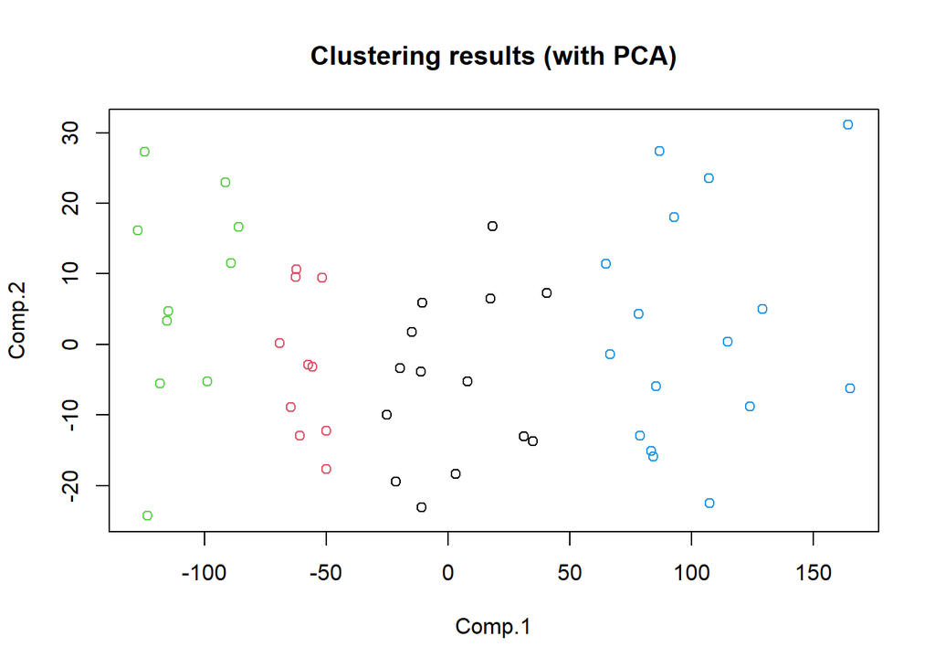

```r
set.seed(123)
kmean_df <- kmeans(df, centers = 4, nstart = 50)
#Simple visualisation of clusters
USArrestsPC <- princomp(USArrests)

plot(USArrestsPC$scores[,1:2], col=kmean_df$cluster, main="Clustering results (with PCA)")
points(kmean_df$centers, pch=3, cex=2)
```

#### c. (1 điểm) Áp dụng hàm `scale()` trên dữ liệu trước khi thực hiện gom cụm phân cấp dùng các phương pháp `single`, `complete`, `average` và `median` trên tập dữ liệu `USArrests`.

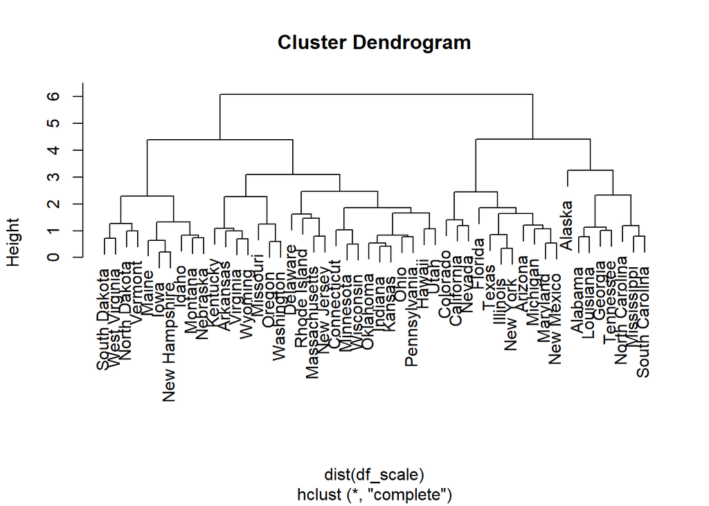

```r
hcl_com = hclust( dist(df_scale), method="complete" )
plot(hcl_com)
```

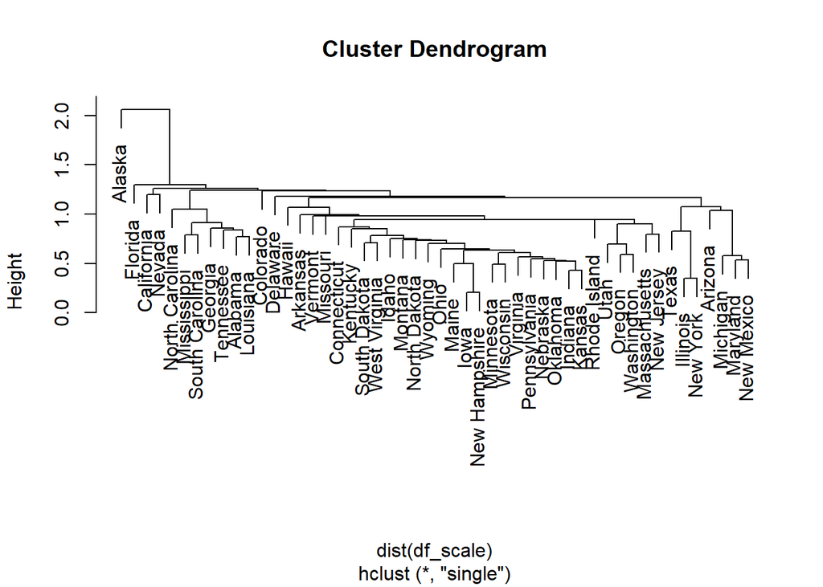

```r
hcl_sin = hclust( dist(df_scale), method="single" )
plot(hcl_sin)
```

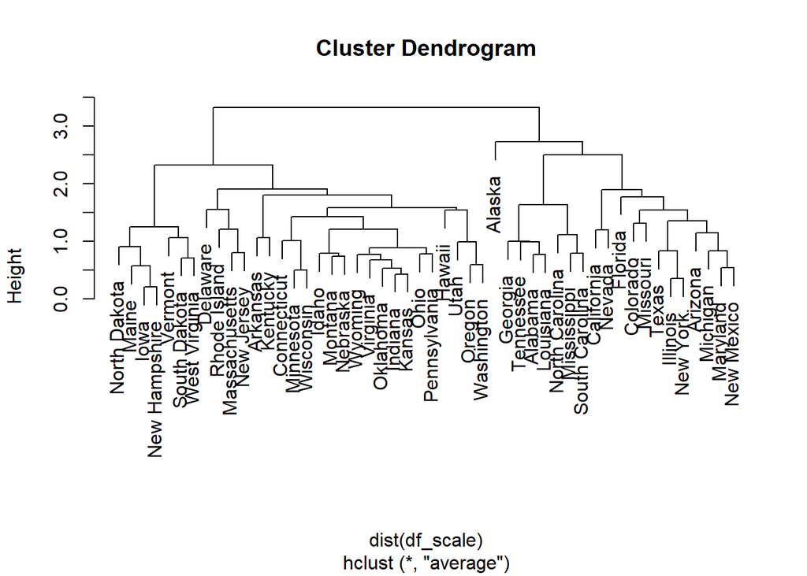

```r
hcl_ave = hclust( dist(df_scale), method="average" )
plot(hcl_ave)
```

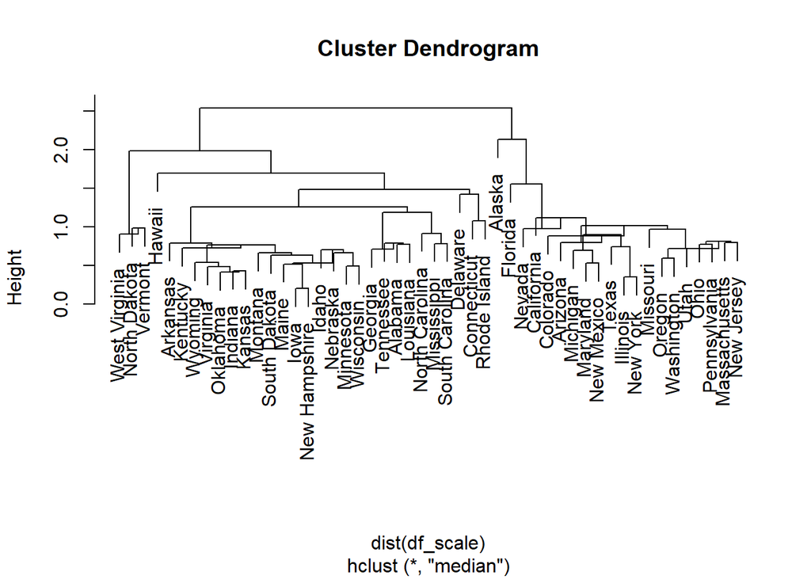

```r
hcl_med = hclust( dist(df_scale), method="median" )
plot(hcl_med)
```

#### d. (0.5 điểm) Cắt dendrogram để thu được 2, 3, 4 cụm. Cho biết kết quả gom cụm tương ứng.

```r
cutree(hcl_com,2)
```

```
##        Alabama         Alaska        Arizona       Arkansas     California
##              1              1              1              2              1
##       Colorado    Connecticut       Delaware        Florida        Georgia
##              1              2              2              1              1
##         Hawaii          Idaho       Illinois        Indiana           Iowa
##              2              2              1              2              2
##         Kansas       Kentucky      Louisiana          Maine       Maryland
##              2              2              1              2              1
##  Massachusetts       Michigan      Minnesota    Mississippi       Missouri
##              2              1              2              1              2
##        Montana       Nebraska         Nevada  New Hampshire     New Jersey
##              2              2              1              2              2
##     New Mexico       New York North Carolina   North Dakota           Ohio
##              1              1              1              2              2
##       Oklahoma         Oregon   Pennsylvania   Rhode Island South Carolina
##              2              2              2              2              1
##   South Dakota      Tennessee          Texas           Utah        Vermont
##              2              1              1              2              2
##       Virginia     Washington  West Virginia      Wisconsin        Wyoming
##              2              2              2              2              2
```

```r
cutree(hcl_com,3)
```

```
##        Alabama         Alaska        Arizona       Arkansas     California
##              1              1              2              3              2
##       Colorado    Connecticut       Delaware        Florida        Georgia
##              2              3              3              2              1
##         Hawaii          Idaho       Illinois        Indiana           Iowa
##              3              3              2              3              3
##         Kansas       Kentucky      Louisiana          Maine       Maryland
##              3              3              1              3              2
##  Massachusetts       Michigan      Minnesota    Mississippi       Missouri
##              3              2              3              1              3
##        Montana       Nebraska         Nevada  New Hampshire     New Jersey
##              3              3              2              3              3
##     New Mexico       New York North Carolina   North Dakota           Ohio
##              2              2              1              3              3
##       Oklahoma         Oregon   Pennsylvania   Rhode Island South Carolina
##              3              3              3              3              1
##   South Dakota      Tennessee          Texas           Utah        Vermont
##              3              1              2              3              3
##       Virginia     Washington  West Virginia      Wisconsin        Wyoming
##              3              3              3              3              3
```

```r
cutree(hcl_com,4)
```

```
##        Alabama         Alaska        Arizona       Arkansas     California
##              1              1              2              3              2
##       Colorado    Connecticut       Delaware        Florida        Georgia
##              2              3              3              2              1
##         Hawaii          Idaho       Illinois        Indiana           Iowa
##              3              4              2              3              4
##         Kansas       Kentucky      Louisiana          Maine       Maryland
##              3              3              1              4              2
##  Massachusetts       Michigan      Minnesota    Mississippi       Missouri
##              3              2              3              1              3
##        Montana       Nebraska         Nevada  New Hampshire     New Jersey
##              4              4              2              4              3
##     New Mexico       New York North Carolina   North Dakota           Ohio
##              2              2              1              4              3
##       Oklahoma         Oregon   Pennsylvania   Rhode Island South Carolina
##              3              3              3              3              1
##   South Dakota      Tennessee          Texas           Utah        Vermont
##              4              1              2              3              4
##       Virginia     Washington  West Virginia      Wisconsin        Wyoming
##              3              3              4              3              3
```

```r
cutree(hcl_sin,2)
```

```
##        Alabama         Alaska        Arizona       Arkansas     California
##              1              2              1              1              1
##       Colorado    Connecticut       Delaware        Florida        Georgia
##              1              1              1              1              1
##         Hawaii          Idaho       Illinois        Indiana           Iowa
##              1              1              1              1              1
##         Kansas       Kentucky      Louisiana          Maine       Maryland
##              1              1              1              1              1
##  Massachusetts       Michigan      Minnesota    Mississippi       Missouri
##              1              1              1              1              1
##        Montana       Nebraska         Nevada  New Hampshire     New Jersey
##              1              1              1              1              1
##     New Mexico       New York North Carolina   North Dakota           Ohio
##              1              1              1              1              1
##       Oklahoma         Oregon   Pennsylvania   Rhode Island South Carolina
##              1              1              1              1              1
##   South Dakota      Tennessee          Texas           Utah        Vermont
##              1              1              1              1              1
##       Virginia     Washington  West Virginia      Wisconsin        Wyoming
##              1              1              1              1              1
```

```r
cutree(hcl_sin,3)
```

```
##        Alabama         Alaska        Arizona       Arkansas     California
##              1              2              1              1              1
##       Colorado    Connecticut       Delaware        Florida        Georgia
##              1              1              1              3              1
##         Hawaii          Idaho       Illinois        Indiana           Iowa
##              1              1              1              1              1
##         Kansas       Kentucky      Louisiana          Maine       Maryland
##              1              1              1              1              1
##  Massachusetts       Michigan      Minnesota    Mississippi       Missouri
##              1              1              1              1              1
##        Montana       Nebraska         Nevada  New Hampshire     New Jersey
##              1              1              1              1              1
##     New Mexico       New York North Carolina   North Dakota           Ohio
##              1              1              1              1              1
##       Oklahoma         Oregon   Pennsylvania   Rhode Island South Carolina
##              1              1              1              1              1
##   South Dakota      Tennessee          Texas           Utah        Vermont
##              1              1              1              1              1
##       Virginia     Washington  West Virginia      Wisconsin        Wyoming
##              1              1              1              1              1
```

```r
cutree(hcl_sin,4)
```

```
##        Alabama         Alaska        Arizona       Arkansas     California
##              1              2              1              1              3
##       Colorado    Connecticut       Delaware        Florida        Georgia
##              1              1              1              4              1
##         Hawaii          Idaho       Illinois        Indiana           Iowa
##              1              1              1              1              1
##         Kansas       Kentucky      Louisiana          Maine       Maryland
##              1              1              1              1              1
##  Massachusetts       Michigan      Minnesota    Mississippi       Missouri
##              1              1              1              1              1
##        Montana       Nebraska         Nevada  New Hampshire     New Jersey
##              1              1              3              1              1
##     New Mexico       New York North Carolina   North Dakota           Ohio
##              1              1              1              1              1
##       Oklahoma         Oregon   Pennsylvania   Rhode Island South Carolina
##              1              1              1              1              1
##   South Dakota      Tennessee          Texas           Utah        Vermont
##              1              1              1              1              1
##       Virginia     Washington  West Virginia      Wisconsin        Wyoming
##              1              1              1              1              1
```

```r
cutree(hcl_ave,2)
```

```
##        Alabama         Alaska        Arizona       Arkansas     California
##              1              1              1              2              1
##       Colorado    Connecticut       Delaware        Florida        Georgia
##              1              2              2              1              1
##         Hawaii          Idaho       Illinois        Indiana           Iowa
##              2              2              1              2              2
##         Kansas       Kentucky      Louisiana          Maine       Maryland
##              2              2              1              2              1
##  Massachusetts       Michigan      Minnesota    Mississippi       Missouri
##              2              1              2              1              1
##        Montana       Nebraska         Nevada  New Hampshire     New Jersey
##              2              2              1              2              2
##     New Mexico       New York North Carolina   North Dakota           Ohio
##              1              1              1              2              2
##       Oklahoma         Oregon   Pennsylvania   Rhode Island South Carolina
##              2              2              2              2              1
##   South Dakota      Tennessee          Texas           Utah        Vermont
##              2              1              1              2              2
##       Virginia     Washington  West Virginia      Wisconsin        Wyoming
##              2              2              2              2              2
```

```r
cutree(hcl_ave,3)
```

```
##        Alabama         Alaska        Arizona       Arkansas     California
##              1              2              1              3              1
##       Colorado    Connecticut       Delaware        Florida        Georgia
##              1              3              3              1              1
##         Hawaii          Idaho       Illinois        Indiana           Iowa
##              3              3              1              3              3
##         Kansas       Kentucky      Louisiana          Maine       Maryland
##              3              3              1              3              1
##  Massachusetts       Michigan      Minnesota    Mississippi       Missouri
##              3              1              3              1              1
##        Montana       Nebraska         Nevada  New Hampshire     New Jersey
##              3              3              1              3              3
##     New Mexico       New York North Carolina   North Dakota           Ohio
##              1              1              1              3              3
##       Oklahoma         Oregon   Pennsylvania   Rhode Island South Carolina
##              3              3              3              3              1
##   South Dakota      Tennessee          Texas           Utah        Vermont
##              3              1              1              3              3
##       Virginia     Washington  West Virginia      Wisconsin        Wyoming
##              3              3              3              3              3
```

```r
cutree(hcl_ave,4)
```

```
##        Alabama         Alaska        Arizona       Arkansas     California
##              1              2              3              4              3
##       Colorado    Connecticut       Delaware        Florida        Georgia
##              3              4              4              3              1
##         Hawaii          Idaho       Illinois        Indiana           Iowa
##              4              4              3              4              4
##         Kansas       Kentucky      Louisiana          Maine       Maryland
##              4              4              1              4              3
##  Massachusetts       Michigan      Minnesota    Mississippi       Missouri
##              4              3              4              1              3
##        Montana       Nebraska         Nevada  New Hampshire     New Jersey
##              4              4              3              4              4
##     New Mexico       New York North Carolina   North Dakota           Ohio
##              3              3              1              4              4
##       Oklahoma         Oregon   Pennsylvania   Rhode Island South Carolina
##              4              4              4              4              1
##   South Dakota      Tennessee          Texas           Utah        Vermont
##              4              1              3              4              4
##       Virginia     Washington  West Virginia      Wisconsin        Wyoming
##              4              4              4              4              4
```

```r
cutree(hcl_med,2)
```

```
##        Alabama         Alaska        Arizona       Arkansas     California
##              1              2              2              1              2
##       Colorado    Connecticut       Delaware        Florida        Georgia
##              2              1              1              2              1
##         Hawaii          Idaho       Illinois        Indiana           Iowa
##              1              1              2              1              1
##         Kansas       Kentucky      Louisiana          Maine       Maryland
##              1              1              1              1              2
##  Massachusetts       Michigan      Minnesota    Mississippi       Missouri
##              2              2              1              1              2
##        Montana       Nebraska         Nevada  New Hampshire     New Jersey
##              1              1              2              1              2
##     New Mexico       New York North Carolina   North Dakota           Ohio
##              2              2              1              1              2
##       Oklahoma         Oregon   Pennsylvania   Rhode Island South Carolina
##              1              2              2              1              1
##   South Dakota      Tennessee          Texas           Utah        Vermont
##              1              1              2              2              1
##       Virginia     Washington  West Virginia      Wisconsin        Wyoming
##              1              2              1              1              1
```

```r
cutree(hcl_med,3)
```

```
##        Alabama         Alaska        Arizona       Arkansas     California
##              1              2              3              1              3
##       Colorado    Connecticut       Delaware        Florida        Georgia
##              3              1              1              3              1
##         Hawaii          Idaho       Illinois        Indiana           Iowa
##              1              1              3              1              1
##         Kansas       Kentucky      Louisiana          Maine       Maryland
##              1              1              1              1              3
##  Massachusetts       Michigan      Minnesota    Mississippi       Missouri
##              3              3              1              1              3
##        Montana       Nebraska         Nevada  New Hampshire     New Jersey
##              1              1              3              1              3
##     New Mexico       New York North Carolina   North Dakota           Ohio
##              3              3              1              1              3
##       Oklahoma         Oregon   Pennsylvania   Rhode Island South Carolina
##              1              3              3              1              1
##   South Dakota      Tennessee          Texas           Utah        Vermont
##              1              1              3              3              1
##       Virginia     Washington  West Virginia      Wisconsin        Wyoming
##              1              3              1              1              1
```

```r
cutree(hcl_med,4)
```

```
##        Alabama         Alaska        Arizona       Arkansas     California
##              1              2              3              1              3
##       Colorado    Connecticut       Delaware        Florida        Georgia
##              3              1              1              3              1
##         Hawaii          Idaho       Illinois        Indiana           Iowa
##              1              1              3              1              1
##         Kansas       Kentucky      Louisiana          Maine       Maryland
##              1              1              1              1              3
##  Massachusetts       Michigan      Minnesota    Mississippi       Missouri
##              3              3              1              1              3
##        Montana       Nebraska         Nevada  New Hampshire     New Jersey
##              1              1              3              1              3
##     New Mexico       New York North Carolina   North Dakota           Ohio
##              3              3              1              4              3
##       Oklahoma         Oregon   Pennsylvania   Rhode Island South Carolina
##              1              3              3              1              1
##   South Dakota      Tennessee          Texas           Utah        Vermont
##              1              1              3              3              4
##       Virginia     Washington  West Virginia      Wisconsin        Wyoming
##              1              3              4              1              1
```

#### f. (0.5 điểm) So sánh Dunn index của các kết quả gom cụm khi áp dụng các thuật toán trên.

```r
d <- dist(USArrests, method="euclidean")
hcl_com <- hclust(d, "complete")
hcl_com.cluster <- cutree(hcl_com, k = 2)
dunn(d, hcl_com.cluster)
```

```
## [1] 0.1532626
```

```r
dunn(d, kmean_df$cluster)
```

```
## [1] 0.2298421
```

#### g. (0.5 điểm) So sánh chỉ số Silhouette của các kết quả gom cụm khi áp dụng các thuật toán trên.

```r
d <- dist(USArrests, method="euclidean")
hcl_com <- hclust(d, "complete")
hcl_com.cluster <- cutree(hcl_com, k = 2)
cl1 <- silhouette(hcl_com.cluster, d)
mean(cl1[, 3])
```

```
## [1] 0.5762705
```

```r
cl2 <- silhouette(kmean_df$cluster, d)
mean(cl2[, 3])
```

```
## [1] 0.5012332
```

### Câu hỏi 2 (6) điểm

Thực hiện thuật toán `kmeans` và `hclust` và `dbscan` cho tập dữ liệu `iris`.

#### a. (1 điểm) Áp dụng `kmeans` với `k = 3` trên tập dữ liệu `iris` sau khi loại bỏ nhãn (thuộc tính `Species`) khỏi tập dữ liệu.

```r
data(iris)
iris_s = iris[iris$Species=="setosa",1:4]
set.seed(1)
iris.cluster <- kmeans(iris_s, center = 3, nstart = 20)
print(iris.cluster)
```

```
## K-means clustering with 3 clusters of sizes 8, 23, 19
##
## Cluster means:
##   Sepal.Length Sepal.Width Petal.Length Petal.Width
## 1     5.512500    4.000000     1.475000    0.275000
## 2     5.100000    3.513043     1.526087    0.273913
## 3     4.678947    3.084211     1.378947    0.200000
##
## Clustering vector:
##  1  2  3  4  5  6  7  8  9 10 11 12 13 14 15 16 17 18 19 20 21 22 23 24 25 26
##  2  3  3  3  2  1  3  2  3  3  1  2  3  3  1  1  1  2  1  2  2  2  3  2  2  3
## 27 28 29 30 31 32 33 34 35 36 37 38 39 40 41 42 43 44 45 46 47 48 49 50
##  2  2  2  3  3  2  1  1  3  3  2  2  3  2  2  3  3  2  2  3  2  3  2  2
##
## Within cluster sum of squares by cluster:
## [1] 0.958750 2.094783 2.488421
##  (between_SS / total_SS =  63.4 %)
##
## Available components:
##
## [1] "cluster"      "centers"      "totss"        "withinss"     "tot.withinss"
## [6] "betweenss"    "size"         "iter"         "ifault"
```

#### b. (1 điểm) Áp dụng `hclust` và cắt dendrogram với k = 3 trên tập dữ liệu `iris` sau khi loại bỏ nhãn (thuộc tính `Species`) khỏi tập dữ liệu.

```r
library(dendextend)
```

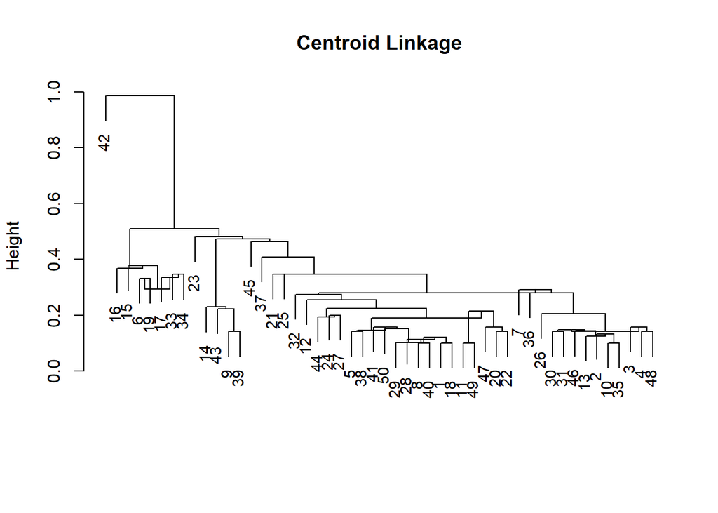

```r
hc.centroid <- hclust(dist(iris_s), "centroid")
plot(hc.centroid, main="Centroid Linkage", xlab="", sub ="", cex =.9)
```

```r
dendro <- as.dendrogram(hclust(dist(iris_s[1:3,])))
labels_colors(dendro) <- 1:3
labels_colors(dendro)
```

```
## 1 2 3
## 1 2 3
```

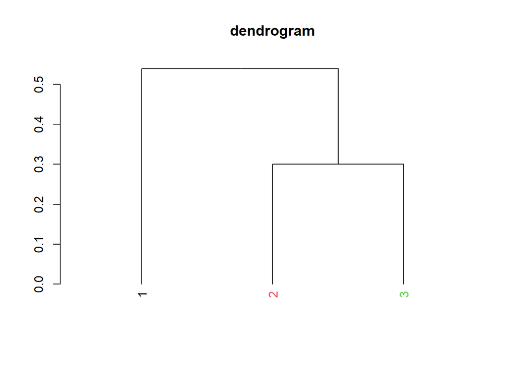

```r
plot(dendro, main = "dendrogram")
```

#### c. (1 điểm) Áp dụng `dbscan` trên tập dữ liệu `iris` sau khi loại bỏ nhãn (thuộc tính Species) khỏi tập dữ liệu.

Hãy thử nghiệm với các tham số `eps` và `minPts` khác nhau và chọn các tham số bạn cho là tốt nhất. Bạn có chiến lược nào để chọn các tham số này không?

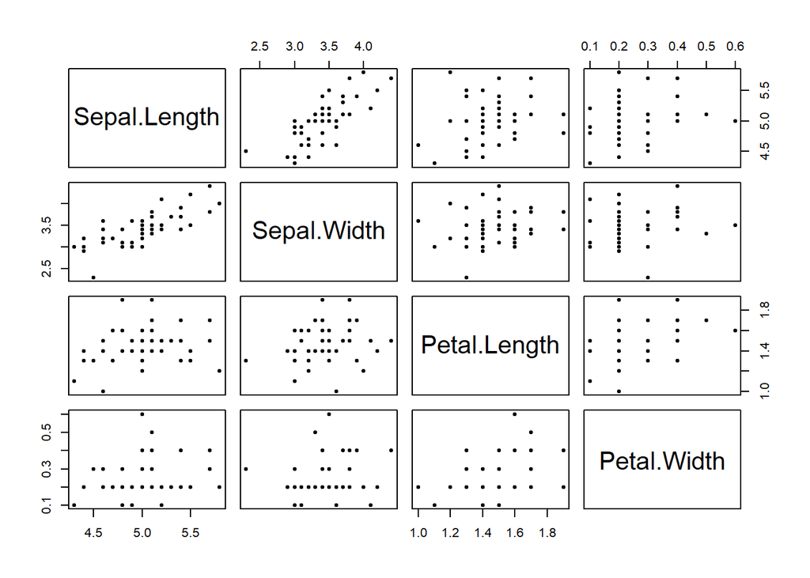

```r
plot(iris_s, pch=20)
```

```r
library(dbscan)
scan <- dbscan(iris_s, eps = 0.5, minPts = 8)
scan
```

```
## DBSCAN clustering for 50 objects.
## Parameters: eps = 0.5, minPts = 8
## The clustering contains 1 cluster(s) and 2 noise points.
##
##  0  1
##  2 48
##
## Available fields: cluster, eps, minPts
```

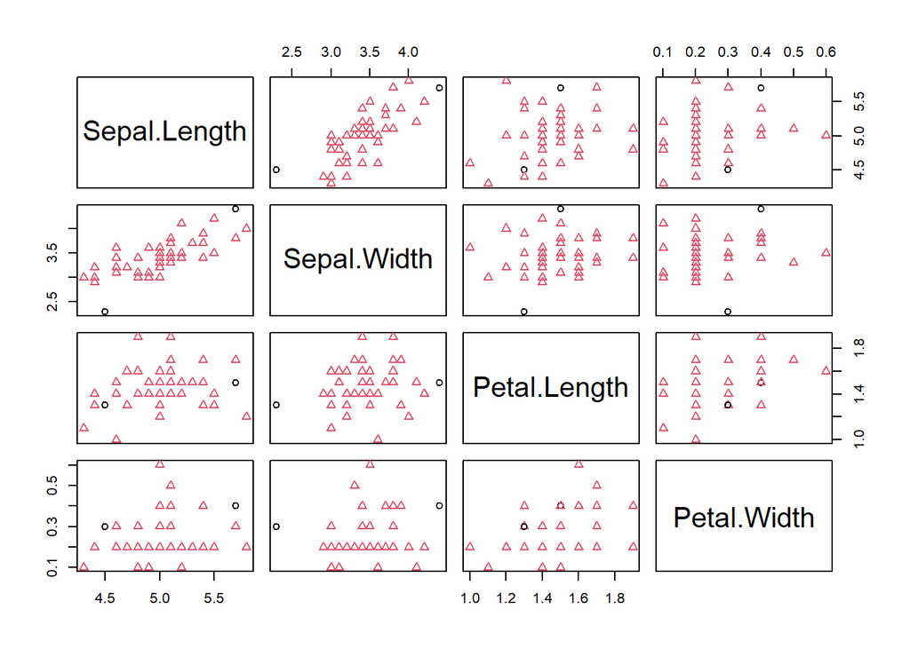

```r
plot(iris_s, col = scan$cluster + 1L, pch = scan$cluster + 1L)
```

#### d. (3 điểm) Sử dụng thuộc tính `Species` làm nhãn cụm thật sự, hãy tính và so sánh Precison, Recall, và F-measure của kết quả gom cụm (theo công thức được định nghĩa như bên dưới) khi dùng `kmeans`, `hclust` và `dbscan`.

Giả sử tập dữ liệu $D$ có $n$ phần tử $x_i$ được phân hoạch thành $p$ nhóm (ở đây ứng với số loài). Gọi $y_i \in \{1, 2, · · · , p\}$ là nhóm thật sự (ground-truth labels) cho mỗi phần tử. Ground-truth clustering được cho bởi $T = \{T_1, T_2, \cdots , T_p\}$, với $T_j$ bao gồm tất cả các phần tử có nhãn $j$, nghĩa là, $T_j = \{ x_i \in D | y_i = j \}$. Mặt khác, gọi $C = \{ C_1, C_2, \cdots, C_k \}$ là một kết quả gom cụm của $D$ thành $k$ cụm (cluster), qua một thuật toán gom cụm nào đó, và $\hat{y_i} \in \{ 1, 2, \cdots, k \}$ là cluster label cho $x_i$. Ta sẽ xem $T$ là một phân hoạch chuẩn (ground-truth partitioning) và mỗi $T_i$ là một phân vùng (partition). Ta gọi $C$ là một kết quả gom cụm (clustering), với mỗi $C_i$ là một cụm (cluster). Giả sử ground truth là biết trước, một thuật toán gom cụm sẽ thực hiện gom cụm trên $D$ với số cụm chính xác, tức với $k = p$. Tuy nhiên, để giữ tính tổng quát, ta cho phép $k \ne p$.

Contingency table of clustering results

| Clusters/Species | *T*<sub>1</sub> | *T*<sub>2</sub> | $…$ | *T*<sub>*p*</sub> |
| --- | --- | --- | --- | --- |
| *C*<sub>1</sub> | *n*<sub>11</sub> | *n*<sub>12</sub> | $…$ | *n*<sub>1*p*</sub> |
| *C*<sub>2</sub> | *n*<sub>21</sub> | *n*<sub>22</sub> | $…$ | *n*<sub>2*p*</sub> |
| $…$ | $…$ | $…$ | $…$ | $…$ |
| *C*<sub>*k*</sub> | *n*<sub>*k*1</sub> | *n*<sub>*k*2</sub> | $…$ | *n*<sub>*k**p*</sub> |

$$N(i, j) = n_{ij} = |C_i \cap
T_j|$$

- $Recall$ là tỷ lệ đối tượng cùng loài được gán cùng cụm.
- $Precision$ là tỷ lệ đối tượng được gán cùng cụm thuộc cùng loài.
- $F{\text -}measure$ là một độ đo cân bằng giữa $Precision$ và $Recall$ và được tính bằng trung bình điều hòa giữa $Precision$ và $Recall$. Đây là một độ đo thường được sử dụng để so sánh các thuật toán gom cụm với nhau.

$$\begin{equation}
precision = \frac{{\sum\limits_{i = 1}^k {\mathop {{\rm{max}}}\limits_{j
\in \left\{ {1, \ldots p} \right\}} \{n_{ij}\} } }}{{\sum\limits_{i =
1}^k {\sum\limits_{j = 1}^p {n_{ij} } } }}
\end{equation}$$

$$\begin{equation}
recall = \frac{{\sum\limits_{j = 1}^p {\mathop {{\rm{max}}}\limits_{i
\in \left\{ {1, \ldots ,k} \right\}} \{n_{ij}\} } }}{{\sum\limits_{i =
1}^k {\sum\limits_{j = 1}^p {n_{ij} } } }}
\end{equation}$$

$$\begin{equation}
\begin{split}
F{\text -}measure = \frac{{2 \cdot precision \cdot recall}}{{precision +
recall}}
\end{split}
\end{equation}$$